# Уменьшение размерности: PCA, LDA, CA, MCA

Г. Мороз

### 1. Введение

Метод главных компонент (PCA, Principal Component Analysis) применим к числовым данным, в которых строчки — это точки наблюдения, а столбцы — это исследуемые переменные. Данный метод часто приводят и используют как метод уменьшения размерности, однако я разделяю мнение, согласно которому это лишь метод смены перспективы, в результаты которого некоторое количество размерностей становится маловажными.

#### 1.1 Библиотеки

```r
library(tidyverse)
library(ggfortify)
library(GGally)
library(ca)
```

#### 1.2 Фамильная честь Вустеров

В данной лекции я буду использовать данные из романа П. Г. Вудхауза [“Фамильная честь Вустеров”](https://en.wikipedia.org/wiki/The_Code_of_the_Woosters). В датасете собраны несколько переменных:

- chapter — номер главы
- гарольд — частотность появления имени в каждой из глав
- гасси — частотность появления имени в каждой из глав
- далия — частотность появления имени в каждой из глав
- дживс — частотность появления имени в каждой из глав
- мадлен — частотность появления имени в каждой из глав
- оутс — частотность появления имени в каждой из глав
- спод — частотность появления имени в каждой из глав
- стиффи — частотность появления имени в каждой из глав
- сэр — частотность появления имени в каждой из глав

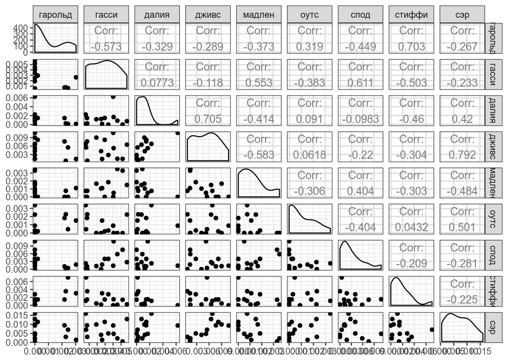

```r
wodehouse <- read.csv("https://goo.gl/8RJDwK")
library(GGally)
ggpairs(wodehouse[,-1])
```

### 2. Дисперсия, ковариация, корреляция Пирсона

$$var(X) = \frac{\sum_{i = 1}^n(x_i - \bar{x})^2}{n - 1}$$

$$cov(X, Y) = \frac{\sum_{i = 1}^n(x_i - \bar{x})(y_i-\bar{y})}{n - 1}$$

```r
cov(wodehouse[,-1])
```

```
##               гарольд         гасси         далия         дживс
## гарольд  1.372875e-06 -1.178804e-06 -6.161597e-07 -1.087033e-06
## гасси   -1.178804e-06  3.079694e-06  2.170550e-07 -6.615942e-07
## далия   -6.161597e-07  2.170550e-07  2.560710e-06  3.618399e-06
## дживс   -1.087033e-06 -6.615942e-07  3.618399e-06  1.029295e-05
## мадлен  -5.017748e-07  1.114755e-06 -7.615052e-07 -2.148603e-06
## оутс     4.177791e-07 -7.493884e-07  1.624905e-07  2.211649e-07
## спод    -1.654950e-06  3.370561e-06 -4.945526e-07 -2.215768e-06
## стиффи   1.555109e-06 -1.666275e-06 -1.389433e-06 -1.843664e-06
## сэр     -1.469249e-06 -1.922950e-06  3.155337e-06  1.193258e-05
##                мадлен          оутс          спод        стиффи
## гарольд -5.017748e-07  4.177791e-07 -1.654950e-06  1.555109e-06
## гасси    1.114755e-06 -7.493884e-07  3.370561e-06 -1.666275e-06
## далия   -7.615052e-07  1.624905e-07 -4.945526e-07 -1.389433e-06
## дживс   -2.148603e-06  2.211649e-07 -2.215768e-06 -1.843664e-06
## мадлен   1.318322e-06 -3.925977e-07  1.459139e-06 -6.577010e-07
## оутс    -3.925977e-07  1.246261e-06 -1.418115e-06  9.103099e-08
## спод     1.459139e-06 -1.418115e-06  9.893695e-06 -1.244713e-06
## стиффи  -6.577010e-07  9.103099e-08 -1.244713e-06  3.568675e-06
## сэр     -2.612465e-06  2.625355e-06 -4.146631e-06 -1.999536e-06
##                   сэр
## гарольд -1.469249e-06
## гасси   -1.922950e-06
## далия    3.155337e-06
## дживс    1.193258e-05
## мадлен  -2.612465e-06
## оутс     2.625355e-06
## спод    -4.146631e-06
## стиффи  -1.999536e-06
## сэр      2.207589e-05
```

$$cor(X, Y) = \frac{cov(X, Y)}{\sigma_X\times\sigma_Y}$$

```r
cor(wodehouse[,-1])
```

```
##            гарольд       гасси       далия       дживс     мадлен
## гарольд  1.0000000 -0.57328735 -0.32862278 -0.28917272 -0.3729775
## гасси   -0.5732873  1.00000000  0.07729222 -0.11750818  0.5532418
## далия   -0.3286228  0.07729222  1.00000000  0.70480092 -0.4144594
## дживс   -0.2891727 -0.11750818  0.70480092  1.00000000 -0.5832781
## мадлен  -0.3729775  0.55324184 -0.41445938 -0.58327808  1.0000000
## оутс     0.3193940 -0.38251524  0.09095850  0.06175072 -0.3062898
## спод    -0.4490452  0.61061743 -0.09825464 -0.21957111  0.4040236
## стиффи   0.7025735 -0.50261963 -0.45962545 -0.30419950 -0.3032245
## сэр     -0.2668830 -0.23321428  0.41966860  0.79159912 -0.4842622
##                оутс        спод      стиффи        сэр
## гарольд  0.31939405 -0.44904519  0.70257349 -0.2668830
## гасси   -0.38251524  0.61061743 -0.50261963 -0.2332143
## далия    0.09095850 -0.09825464 -0.45962545  0.4196686
## дживс    0.06175072 -0.21957111 -0.30419950  0.7915991
## мадлен  -0.30628984  0.40402356 -0.30322448 -0.4842622
## оутс     1.00000000 -0.40385722  0.04316496  0.5005235
## спод    -0.40385722  1.00000000 -0.20947701 -0.2805802
## стиффи   0.04316496 -0.20947701  1.00000000 -0.2252769
## сэр      0.50052346 -0.28058019 -0.22527691  1.0000000
```

### 3. Собственный вектор, собственное значение

Как вы знаете, матрицы можно перемножать. [Подсказка](https://upload.wikimedia.org/wikipedia/commons/e/eb/Matrix_multiplication_diagram_2.svg).

```r
m1 <- matrix(c(2, 2, 3, 1), nrow = 2)
m2 <- matrix(c(1, 3), nrow = 2)
m3 <- matrix(c(3, 2), nrow = 2)
m1
```

```
##      [,1] [,2]
## [1,]    2    3
## [2,]    2    1
```

```r
m2
```

```
##      [,1]
## [1,]    1
## [2,]    3
```

```r
m1 %*% m2
```

```
##      [,1]
## [1,]   11
## [2,]    5
```

```r
m1
```

```
##      [,1] [,2]
## [1,]    2    3
## [2,]    2    1
```

```r
m3
```

```
##      [,1]
## [1,]    3
## [2,]    2
```

```r
m1 %*% m3
```

```
##      [,1]
## [1,]   12
## [2,]    8
```

В первом примере мы получили матрицу $\left(\array{11\\ 5}\right)$, а во втором случае $\left(\array{12\\ 8}\right) = 4 \times \left(\array{3\\ 2}\right)$, т. е. при умножении матрицы мы получили значение, равное скалярному умножению той же самой матрицы.

Мы можем думать об одной матрице, как о векторе $\left(\array{3\\ 2}\right)$ в двумерном пространстве. Тогда матрица $\left(\array{2 & 3\\ 2 & 1}\right)$ — это матрица некоторой трансформации А, которая изменяет вектор $\left(\array{3\\ 2}\right)$. В таком случае **собственный вектор (eigenvector)** — это тот постянный объект, который подвергается трансформации, а **собственное значение (eigenvalues)** — это скалярный мультипликатор собсвтенного вектора (в нашем случае собственное значение равно 4).

Как найти собственный вектор в R:

```r
m <- matrix(c(2, 2, 3, 1), nrow = 2)
eigen(m)
```

```
## eigen() decomposition
## $values
## [1]  4 -1
##
## $vectors
##           [,1]       [,2]
## [1,] 0.8320503 -0.7071068
## [2,] 0.5547002  0.7071068
```

```r
3/sqrt(13)
```

```
## [1] 0.8320503
```

```r
2/sqrt(13)
```

```
## [1] 0.5547002
```

### 4. PCA

Обычно переменные, которые используют в PCA **нужно обязательно нормализовать**, но так как мы будем использовать частотность, эти переменные не нуждаются в нормализации. Давайте сравним результат работы функций, которые мы рассмотрели перед этим и функции `prcomp`.

```r
eigen(cov(wodehouse[,-1]))
```

```
## eigen() decomposition
## $values
## [1] 3.245800e-05 1.196687e-05 4.517294e-06 3.377992e-06 1.319692e-06
## [6] 9.606964e-07 5.074912e-07 2.534438e-07 4.758608e-08
##
## $vectors
##              [,1]        [,2]        [,3]       [,4]        [,5]
##  [1,]  0.04446386  0.26045490 -0.07123814 -0.2007927 -0.19032360
##  [2,]  0.08779348 -0.38160590  0.15116503  0.2628203  0.33907652
##  [3,] -0.15615004 -0.12382054  0.44598913 -0.1200921 -0.57733956
##  [4,] -0.50150883 -0.17557608  0.44773479 -0.4588859  0.25194436
##  [5,]  0.11753413 -0.11397729 -0.02832850  0.3441355  0.25226081
##  [6,] -0.08429973  0.11600713 -0.21296940  0.2130548 -0.52978937
##  [7,]  0.21798564 -0.77103418 -0.39697535 -0.3648273 -0.21338990
##  [8,]  0.07986552  0.33105390 -0.36958846 -0.5731985  0.24597480
##  [9,] -0.79975269 -0.09921106 -0.48203526  0.2003306  0.04069356
##              [,6]        [,7]        [,8]        [,9]
##  [1,] -0.21673241  0.62957491 -0.34447525  0.53532218
##  [2,] -0.78159891  0.13186661  0.10619326  0.01443264
##  [3,] -0.25790782 -0.50008339 -0.12601954  0.28487803
##  [4,]  0.07393053  0.25634369 -0.25181765 -0.32947429
##  [5,]  0.13479280 -0.23614522 -0.84496615  0.04925650
##  [6,] -0.27686794  0.18859046 -0.22734885 -0.66640912
##  [7,]  0.11194383  0.06916025 -0.06534478  0.01343150
##  [8,] -0.39980733 -0.40770488 -0.13773815 -0.11544756
##  [9,] -0.05427500 -0.09007671  0.04324016  0.25194682
```

```r
PCA <- prcomp(wodehouse[,-1])
PCA
```

```
## Standard deviations (1, .., p=9):
## [1] 0.0056971923 0.0034593165 0.0021253926 0.0018379315 0.0011487786
## [6] 0.0009801512 0.0007123842 0.0005034320 0.0002181423
##
## Rotation (n x k) = (9 x 9):
##                 PC1         PC2         PC3        PC4         PC5
## гарольд  0.04446386 -0.26045490  0.07123814 -0.2007927  0.19032360
## гасси    0.08779348  0.38160590 -0.15116503  0.2628203 -0.33907652
## далия   -0.15615004  0.12382054 -0.44598913 -0.1200921  0.57733956
## дживс   -0.50150883  0.17557608 -0.44773479 -0.4588859 -0.25194436
## мадлен   0.11753413  0.11397729  0.02832850  0.3441355 -0.25226081
## оутс    -0.08429973 -0.11600713  0.21296940  0.2130548  0.52978937
## спод     0.21798564  0.77103418  0.39697535 -0.3648273  0.21338990
## стиффи   0.07986552 -0.33105390  0.36958846 -0.5731985 -0.24597480
## сэр     -0.79975269  0.09921106  0.48203526  0.2003306 -0.04069356
##                 PC6         PC7         PC8         PC9
## гарольд -0.21673241  0.62957491 -0.34447525  0.53532218
## гасси   -0.78159891  0.13186661  0.10619326  0.01443264
## далия   -0.25790782 -0.50008339 -0.12601954  0.28487803
## дживс    0.07393053  0.25634369 -0.25181765 -0.32947429
## мадлен   0.13479280 -0.23614522 -0.84496615  0.04925650
## оутс    -0.27686794  0.18859046 -0.22734885 -0.66640912
## спод     0.11194383  0.06916025 -0.06534478  0.01343150
## стиффи  -0.39980733 -0.40770488 -0.13773815 -0.11544756
## сэр     -0.05427500 -0.09007671  0.04324016  0.25194682
```

Как читать полученное? Мы сменили оси координат и в новом пространстве (точно так же 9-мерном) мы можем перейти используя полученные значения:

$$PC1 = гарольд \times 0.04446386 + гасси \times 0.08779348 + далия \times -0.15615004 + дживс \times -0.50150883 +$$
$$+ мадлен \times 0.11753413 + оутс \times -0.08429973 + спод \times 0.21798564 + стиффи \times 0.07986552 + сэр \times -0.79975269$$

Как полученные компоненты объясняют дисперсию в переменных?

```r
summary(PCA)
```

```
## Importance of components:
##                             PC1      PC2      PC3      PC4      PC5
## Standard deviation     0.005697 0.003459 0.002125 0.001838 0.001149
## Proportion of Variance 0.585790 0.215970 0.081530 0.060960 0.023820
## Cumulative Proportion  0.585790 0.801760 0.883290 0.944250 0.968070
##                              PC6       PC7       PC8       PC9
## Standard deviation     0.0009802 0.0007124 0.0005034 0.0002181
## Proportion of Variance 0.0173400 0.0091600 0.0045700 0.0008600
## Cumulative Proportion  0.9854100 0.9945700 0.9991400 1.0000000
```

Т. е. первые две компоненты объясняют почти 80 процентов дисперсии, это достаточно высокое значение, которое позволяет нам применять данный метод.

В выдаче PCA мы видели порядок, который отображает порядок следования в датасете, чтобы не потерять информацию о главе, мы прибегнем к хитрости:

```r
wodehouse_2 <- wodehouse[,-1]
rownames(wodehouse_2) <- wodehouse[, 1]
PCA <- prcomp(wodehouse_2)
```

Дальнейшая визуализация возможна благодаря пакету `ggfortify`:

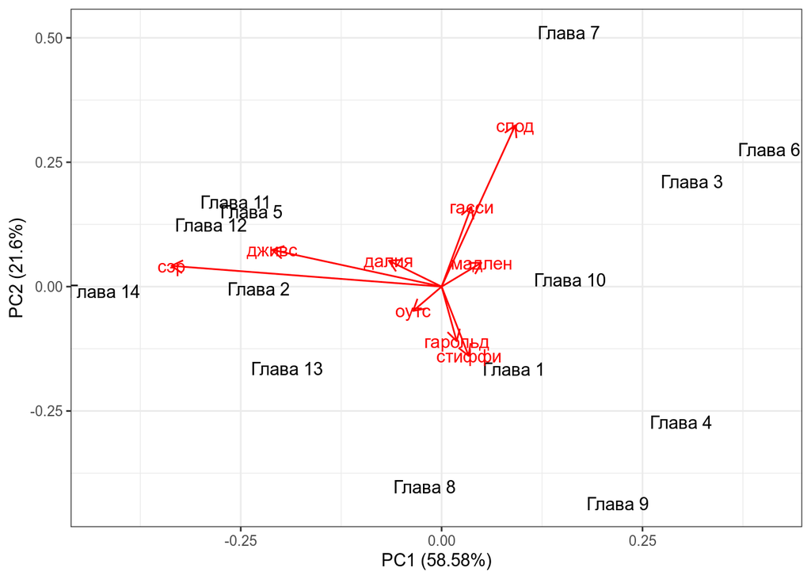

```r
library(ggfortify)
autoplot(PCA,
         shape = FALSE,
         loadings = TRUE,
         label = TRUE,
         loadings.label = TRUE)
```

Числа на этом графике — номера глав романа, красные линии — оси старых осей координат. Сам график называется биплот. Чем ближе друг к другустарые оси координат, тем больше скоррелированы переменные (вообще, косинус угла между ними равен коэфициенту корреляции между соответствующими переменными).

### 5. Что дальше?

- После того как преобразование сделано можно запскать стандартные методы регрессии, кластеризации и т. д.
- можно использовать некоторые не затронутые в PCA переменные, для анализа в новом пространстве

### 6. 3d пример от Ильи Щурова

[ссылка](http://math-info.hse.ru/f/2015-16/ling-mag-quant/lecture-pca.html#%D0%A2%D1%80%D1%91%D1%85%D0%BC%D0%B5%D1%80%D0%BD%D1%8B%D0%B9%20%D0%BF%D1%80%D0%B8%D0%BC%D0%B5%D1%80)

### 7. Евангелия

```r
gospels <- read.csv("https://tinyurl.com/y8tcf3uw")
```

Постройте PCA и нарисуйте биплот. Чем вызвано такое расхождение евангелистов?

### 8. Линейный дискриминантный анализ

Линейный дискриминантный анализ (Linear Discriminant Analysis, LDA) очень близок к PCA, но его основная цель — максимизировать разделяемость известных категорий. Так что если PCA пытается перейти к новым осям координат, беря за основу наибольшую дисперсию в многомерном пространстве, LDA переходит к новым координатам, стараясь оптимизировать разницу между средними и дисперсией известных групп.

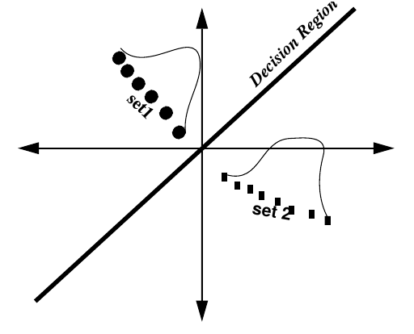

### 9. Сравнение PCA и LDA

#### 9.1 Нанайские данные

В этом датасете представлены три нанайских гласных i, ɪ и e, произнесенные нанайским носителем мужского пола из селения Джуен. Каждая строчка — отдельное произнесение. Переменные:

- f1 — первая форманта
- f2 — вторая форманта

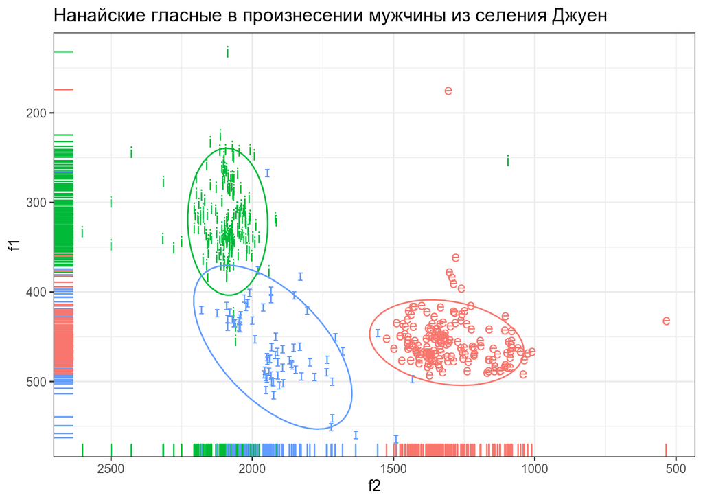

```r
nanai <- read_csv("https://goo.gl/9uGBoQ")
nanai %>%
  ggplot(aes(f2, f1, label = sound, color = sound))+
  geom_text()+
  geom_rug()+
  scale_y_reverse()+
  scale_x_reverse()+
  stat_ellipse()+
  theme(legend.position = "none")+
  labs(title = "Нанайские гласные в произнесении мужчины из селения Джуен")
```

Применим PCA. Обязательно нормировать переменные:

```r
pca <- prcomp(nanai[, -1], center = TRUE, scale. = TRUE)
summary(pca)
```

```
## Importance of components:
##                           PC1    PC2
## Standard deviation     1.2959 0.5663
## Proportion of Variance 0.8397 0.1603
## Cumulative Proportion  0.8397 1.0000
```

```r
prop.pca <- paste0(c("PCA1 ", "PCA2 "),
                   "(",
                   round(pca$sdev^2/sum(pca$sdev^2), 2),
                   "%)")
prop.pca
```

```
## [1] "PCA1 (0.84%)" "PCA2 (0.16%)"
```

Применим LDA:

```r
lda <- MASS::lda(sound ~ f1 + f2, nanai)
lda
```

```
## Call:
## lda(sound ~ f1 + f2, data = nanai)
##
## Prior probabilities of groups:
##         e         i         ɪ
## 0.3776722 0.4489311 0.1733967
##
## Group means:
##         f1       f2
## e 452.8164 1295.328
## i 318.2667 2092.761
## ɪ 458.9413 1907.553
##
## Coefficients of linear discriminants:
##             LD1         LD2
## f1 -0.009603642 0.024154629
## f2  0.006947067 0.003913338
##
## Proportion of trace:
##    LD1    LD2
## 0.9072 0.0928
```

```r
prop.lda <- paste0(c("LDA1 ", "LDA2 "),
                   "(",
                   round(lda$svd^2/sum(lda$svd^2), 2),
                   "%)")
prop.lda
```

```
## [1] "LDA1 (0.91%)" "LDA2 (0.09%)"
```

```r
plda <- predict(object = lda, newdata = nanai)
head(plda$x)
```

```
##         LD1         LD2
## 1  2.755845  0.08781396
## 2  1.414956  0.29058264
## 3 -3.272616 -5.98204507
## 4  4.981263 -0.65448203
## 5  2.237146 -0.75823208
## 6  6.042266  0.62783102
```

Соединим все в один датасет:

```r
dataset <- data.frame(sound = nanai[,"sound"],
                      pca = pca$x,
                      lda = plda$x)
```

Визуализируем:

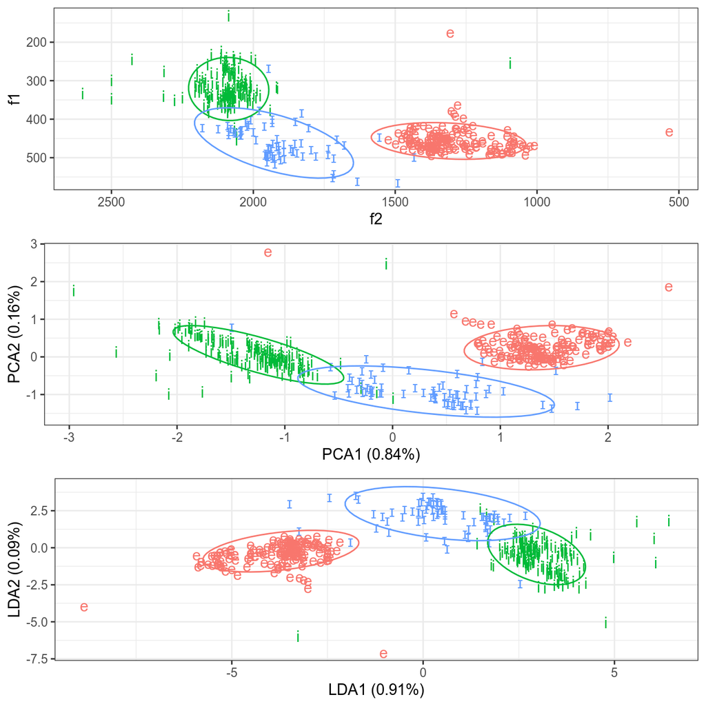

```r
nanai %>%
  ggplot(aes(f2, f1, label = sound, color = sound))+
  geom_text()+
  scale_y_reverse()+
  scale_x_reverse()+
  stat_ellipse()+
  theme(legend.position = "none") ->
  p1

dataset %>%
  ggplot(aes(pca.PC1, pca.PC2, colour = sound, label = sound)) +
  geom_text() +
  labs(x = prop.pca[1], y = prop.pca[2])+
  stat_ellipse() +
  theme(legend.position = "none") ->
  p2

dataset %>%
  ggplot(aes(lda.LD1, lda.LD2, colour = sound, label = sound)) +
  geom_text() +
  labs(x = prop.lda[1], y = prop.lda[2])+
  stat_ellipse() +
  theme(legend.position = "none") ->
  p3

gridExtra::grid.arrange(p1, p2, p3)
```

#### 9.2 Register variation in the British National Corpus

Dataset and discription from Natalia Levshina’s package `Rling`. This is a data set with relative frequencies (proportions) of different word classes in 69 subcorpora of the [British National Corpus](http://corpus.byu.edu/bnc) (the BYU-BNC version).

- Reg — a factor that describes the metaregister with levels Acad, Fiction, Misc, News, NonacProse and Spok
- Ncomm — a numeric vector with relative frequencies of common nouns.
- Nprop — a numeric vector with relative frequencies of proper nouns.
- Vpres — a numeric vector with relative frequencies of verbs in the present tense form, 3rd person singular.
- Vpast — a numeric vector with relative frequencies of verbs in the past tense form.
- P1 — a numeric vector with relative frequencies of the first-person pronouns.
- P2 — a numeric vector with relative frequencies of the second-person pronouns.
- Adj — a numeric vector with relative frequencies of adjectives.
- ConjCoord — a numeric vector with relative frequencies of coordinating conjunctions.
- ConjSub — a numeric vectorwith relative frequencies of subordinating conjunctions.
- Interject — a numeric vector with relative frequencies of interjections.
- Num — a numeric vector with relative frequencies of numerals.

```r
reg_bnc <- read.csv("https://goo.gl/19QywL")
```

Применим PCA. Обязательно нормировать переменные:

```r
pca <- prcomp(reg_bnc[, -1], center = TRUE, scale. = TRUE)
summary(pca)
```

```
## Importance of components:
##                           PC1    PC2    PC3     PC4     PC5     PC6    PC7
## Standard deviation     2.2513 1.3683 1.1730 0.88886 0.80320 0.64940 0.5480
## Proportion of Variance 0.4607 0.1702 0.1251 0.07183 0.05865 0.03834 0.0273
## Cumulative Proportion  0.4607 0.6310 0.7560 0.82786 0.88650 0.92484 0.9521
##                            PC8     PC9    PC10    PC11
## Standard deviation     0.43204 0.37908 0.32981 0.29551
## Proportion of Variance 0.01697 0.01306 0.00989 0.00794
## Cumulative Proportion  0.96911 0.98217 0.99206 1.00000
```

```r
prop.pca <- paste0(c("PCA1 ", "PCA2 "),
                   "(",
                   round(pca$sdev^2/sum(pca$sdev^2), 2)*100,
                   "%)")
prop.pca
```

```
##  [1] "PCA1 (46%)" "PCA2 (17%)" "PCA1 (13%)" "PCA2 (7%)"  "PCA1 (6%)"
##  [6] "PCA2 (4%)"  "PCA1 (3%)"  "PCA2 (2%)"  "PCA1 (1%)"  "PCA2 (1%)"
## [11] "PCA1 (1%)"
```

Применим LDA:

```r
lda <- MASS::lda(Reg ~ ., reg_bnc) # точка здесь означает все остальные переменные
lda
```

```
## Call:
## lda(Reg ~ ., data = reg_bnc)
##
## Prior probabilities of groups:
##       Acad    Fiction       Misc       News NonacProse       Spok
## 0.08695652 0.04347826 0.20289855 0.23188406 0.08695652 0.34782609
##
## Group means:
##                Ncomm      Nprop      Vpres      Vpast          P1
## Acad       0.2549420 0.02266485 0.02904719 0.02126151 0.004105998
## Fiction    0.1955041 0.04178816 0.03038170 0.04548496 0.030593736
## Misc       0.2343928 0.03550175 0.02651374 0.02315834 0.013141775
## News       0.2378307 0.07106673 0.02822461 0.03365907 0.007803970
## NonacProse 0.2499477 0.04212051 0.02589905 0.02704461 0.004550642
## Spok       0.1687050 0.01799012 0.03893423 0.02438672 0.030547406
##                      P2        Adj  ConjCoord    ConjSub    Interject
## Acad       0.0005405686 0.09482774 0.03543711 0.02442643 0.0001529274
## Fiction    0.0157916198 0.06244320 0.03530775 0.02052828 0.0032991461
## Misc       0.0056901996 0.07606038 0.03649929 0.02321892 0.0004648388
## News       0.0020222830 0.07388502 0.03036116 0.01913741 0.0003298421
## NonacProse 0.0027800044 0.08578270 0.03628245 0.02212339 0.0002005514
## Spok       0.0219079840 0.05286300 0.03723121 0.03175828 0.0118121512
##                    Num
## Acad       0.027937153
## Fiction    0.008623133
## Misc       0.023046086
## News       0.026427816
## NonacProse 0.024857053
## Spok       0.022938509
##
## Coefficients of linear discriminants:
##                  LD1         LD2        LD3         LD4          LD5
## Ncomm     -14.975910   33.038613  -13.75794   -9.762794   -0.3627041
## Nprop     -31.817659    1.680262  -51.20818  -26.679090  -17.4961099
## Vpres      21.949722   77.322406  -17.27444  137.775687   26.8626816
## Vpast     -19.768647   80.118231   10.44288   93.006137  -19.1976952
## P1         29.248688  107.556231   83.43757   36.133339   88.1194007
## P2        -24.775453  131.904744   12.86914   23.705959 -105.8680052
## Adj       -31.055573  -31.813406   65.91946   99.586559  -14.1475120
## ConjCoord 112.139915 -163.557542  -35.33204 -159.069109  -61.6664488
## ConjSub    91.669633 -125.858658 -173.82587  -33.940312  -58.0035162
## Interject   3.624572 -128.365272 -100.95408  -16.955043  -33.7161488
## Num        75.705268  -95.261979  -28.39224   79.729523   41.6955600
##
## Proportion of trace:
##    LD1    LD2    LD3    LD4    LD5
## 0.6095 0.2670 0.0782 0.0419 0.0034
```

```r
prop.lda <- paste0(c("LDA1 ", "LDA2 "),
                   "(",
                   round(lda$svd^2/sum(lda$svd^2), 2)*100,
                   "%)")
prop.lda
```

```
## [1] "LDA1 (61%)" "LDA2 (27%)" "LDA1 (8%)"  "LDA2 (4%)"  "LDA1 (0%)"
```

```r
plda <- predict(object = lda, newdata = reg_bnc)
```

Соединим все в один датасет:

```r
dataset <- data.frame(Reg = reg_bnc[,"Reg"],
                      pca = pca$x,
                      lda = plda$x)
```

Визуализируем:

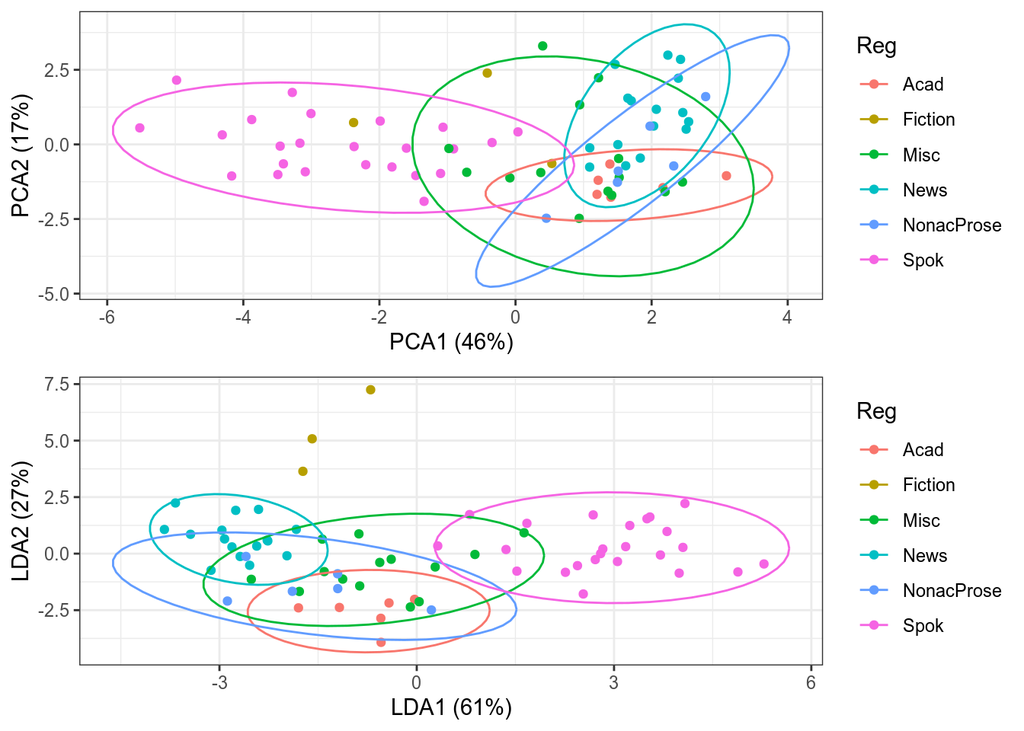

```r
dataset %>%
  ggplot(aes(pca.PC1, pca.PC2, colour = Reg)) +
  geom_point() +
  labs(x = prop.pca[1], y = prop.pca[2])+
  stat_ellipse() ->
  p1

dataset %>%
  ggplot(aes(lda.LD1, lda.LD2, colour = Reg)) +
  geom_point() +
  labs(x = prop.lda[1], y = prop.lda[2])+
  stat_ellipse() ->
  p2

gridExtra::grid.arrange(p1, p2)
```

### 10. Введение

#### 10.1 Фамильная честь Вустеров

В данной лекции я буду использовать данные из романа П. Г. Вудхауза [“Фамильная честь Вустеров”](https://en.wikipedia.org/wiki/The_Code_of_the_Woosters). В датасете собраны несколько переменных:

- chapter — номер главы
- гарольд — количество появлений имени в каждой из глав
- гасси — количество появлений имени в каждой из глав
- далия — количество появлений имени в каждой из глав
- дживс — количество появлений имени в каждой из глав
- мадлен — количество появлений имени в каждой из глав
- оутс — количество появлений имени в каждой из глав
- спод — количество появлений имени в каждой из глав
- стиффи — количество появлений имени в каждой из глав
- сэр — количество появлений имени в каждой из глав

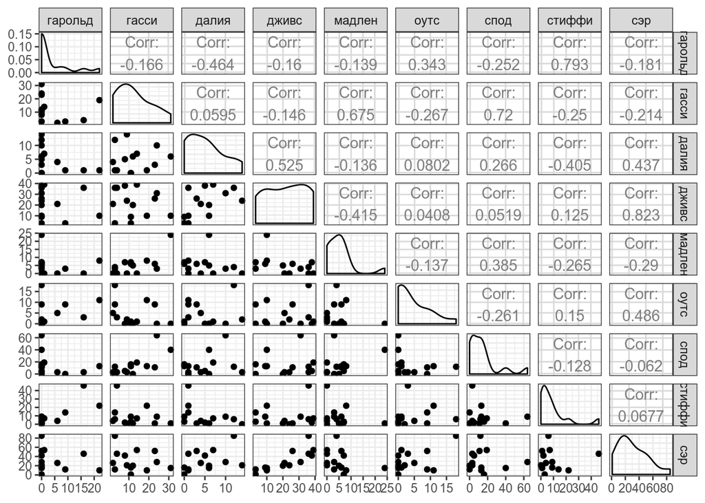

```r
wodehouse <- read.csv("https://goo.gl/bSxdMZ")
GGally::ggpairs(wodehouse[,-1])
```

#### 10.2 Нидерланлские каузативы

Dataset and description from [paper by Natalia Levshina](https://goo.gl/v6AmVj). Modern standard Dutch has two periphrastic causatives with the infinitive: the constructions with doen ‘do’ and laten ‘let’. The study is based on an 8-million token corpus of Netherlandic and Belgian Dutch. After the manual cleaning, there were left with 6,808 observations, which were then coded for seven semantic, syntactic, geographical and thematic variables.

- Aux — a factor that specifies the causative auxiliary with levels laten and doen.
- Country — a factor with levels NL (the Netherlands) and BE (Belgium).
- Causation — a factor that describes the type of causation with levels Affective, Inducive, Physical and Volitional
- EPTrans — a factor that specifies the transitivity of the Effected Predicate with levels Intr (intransitive) and Tr (transitive).
- EPTrans1 — a factor with levels Intr and Tr. It is very similar to the previous one, except for a few observations.

```r
dutch_caus <- read.csv("https://goo.gl/2yAR3T")
```

### 11. CA

```r
rownames(wodehouse) <- wodehouse$chapter
ca <- ca(wodehouse[-1])
ca
```

```
##
##  Principal inertias (eigenvalues):
##            1        2        3        4        5        6        7
## Value      0.269248 0.208594 0.063634 0.041687 0.034383 0.012929 0.008438
## Percentage 42.07%   32.59%   9.94%    6.51%    5.37%    2.02%    1.32%
##            8
## Value      0.00111
## Percentage 0.17%
##
##
##  Rows:
##           Глава 1  Глава 10  Глава 11  Глава 12  Глава 13  Глава 14
## Mass     0.042924  0.043595  0.087860  0.048960  0.047619  0.118042
## ChiDist  0.657319  0.503827  0.480650  0.871805  0.584273  0.664054
## Inertia  0.018546  0.011066  0.020298  0.037212  0.016256  0.052053
## Dim. 1  -0.323423 -0.420878 -0.225240 -0.223638  0.791993  0.310647
## Dim. 2  -0.829703  0.638712 -0.563479 -1.328967 -0.653949 -1.109652
##           Глава 2   Глава 3  Глава 4   Глава 5   Глава 6   Глава 7
## Mass     0.071764  0.085178 0.077800  0.095238  0.027498  0.113347
## ChiDist  0.594474  1.048459 1.064355  0.412476  1.195103  0.778320
## Inertia  0.025361  0.093633 0.088136  0.016203  0.039275  0.068663
## Dim. 1  -0.135807 -1.654098 1.093472 -0.136037 -1.654453 -1.088398
## Dim. 2  -1.034327  1.123948 1.807475 -0.718441  1.770157  0.450153
##          Глава 8  Глава 9
## Mass    0.103957 0.036217
## ChiDist 0.966054 1.246820
## Inertia 0.097019 0.056302
## Dim. 1  1.587645 1.958257
## Dim. 2  0.446586 1.232483
##
##
##  Columns:
##          гарольд     гасси     далия     дживс    мадлен     оутс
## Mass    0.036217  0.116700  0.046948  0.205231  0.048960 0.039571
## ChiDist 1.734289  0.641171  0.882726  0.429982  1.146279 1.162493
## Inertia 0.108933  0.047976  0.036582  0.037944  0.064332 0.053476
## Dim. 1  2.558838 -0.872498 -0.458448  0.091883 -1.191267 1.337131
## Dim. 2  2.163571  0.681049 -1.147145 -0.787378  1.304640 0.046829
##              спод   стиффи       сэр
## Mass     0.135480 0.083836  0.287056
## ChiDist  0.948004 1.145983  0.453071
## Inertia  0.121757 0.110100  0.058925
## Dim. 1  -1.422440 1.658337  0.247022
## Dim. 2   0.985778 1.331784 -0.882475
```

```r
summary(ca) # extended results
```

```
##
## Principal inertias (eigenvalues):
##
##  dim    value      %   cum%   scree plot
##  1      0.269248  42.1  42.1  ***********
##  2      0.208594  32.6  74.7  ********
##  3      0.063634   9.9  84.6  **
##  4      0.041687   6.5  91.1  **
##  5      0.034383   5.4  96.5  *
##  6      0.012929   2.0  98.5  *
##  7      0.008438   1.3  99.8
##  8      0.001110   0.2 100.0
##         -------- -----
##  Total: 0.640025 100.0
##
```

[output cut: 29 more lines]

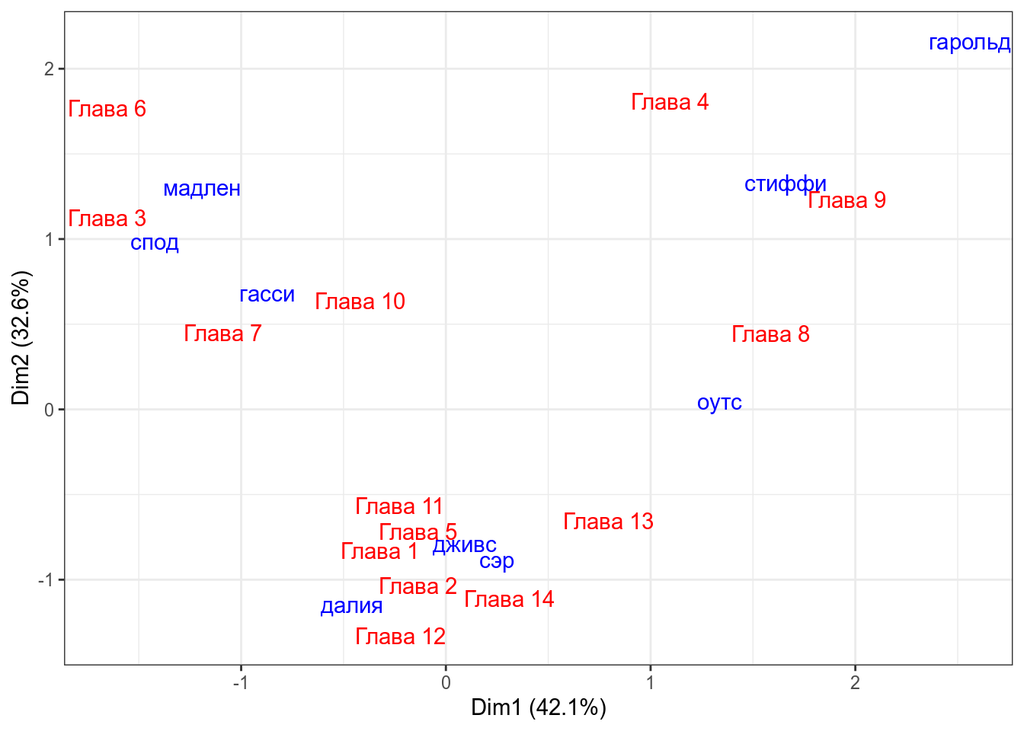

```r
wodehouse_col <- data.frame(ca$colcoord)
wodehouse_col$rows <- rownames(ca$colcoord)

wodehouse_row <- data.frame(ca$rowcoord)
wodehouse_row$rows <- rownames(ca$rowcoord)

wodehouse_col %>%
  ggplot(aes(Dim1, Dim2, label = rows))+
  geom_text(color = "blue")+
  geom_text(data = wodehouse_row, color = "red")+
  theme_bw()+
  labs(x = "Dim1 (42.1%)",
       y = "Dim2 (32.6%)")
```

Сравните с соответствующими данными PCA:

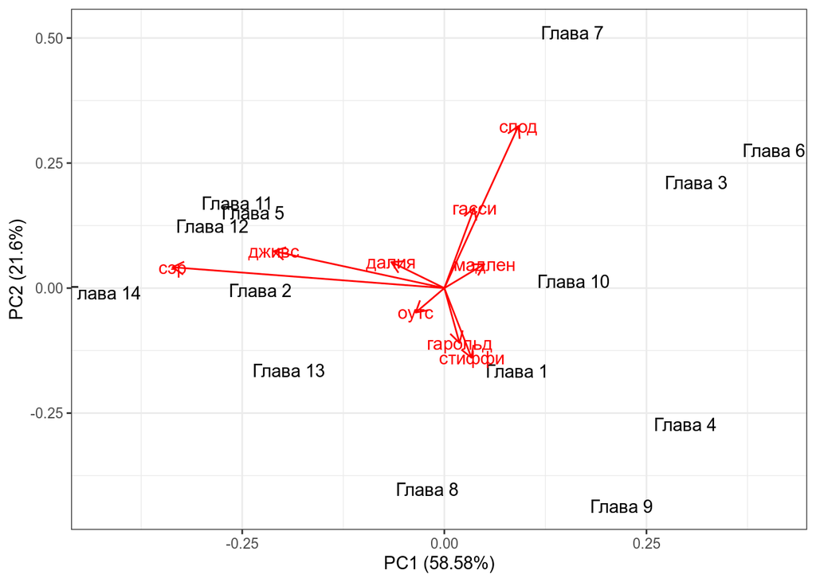

### 12. MCA

```r
MCA <- MASS::mca(dutch_caus[,-1])
MCA
```

```
## Call:
## MASS::mca(df = dutch_caus[, -1])
##
## Multiple correspondence analysis of 500 cases of 7 factors
##
## Correlations 0.577 0.458  cumulative % explained  9.62 17.25
```

```r
dutch_caus <- cbind(dutch_caus, MCA$rs)
variables <- as_data_frame(MCA$cs)
```

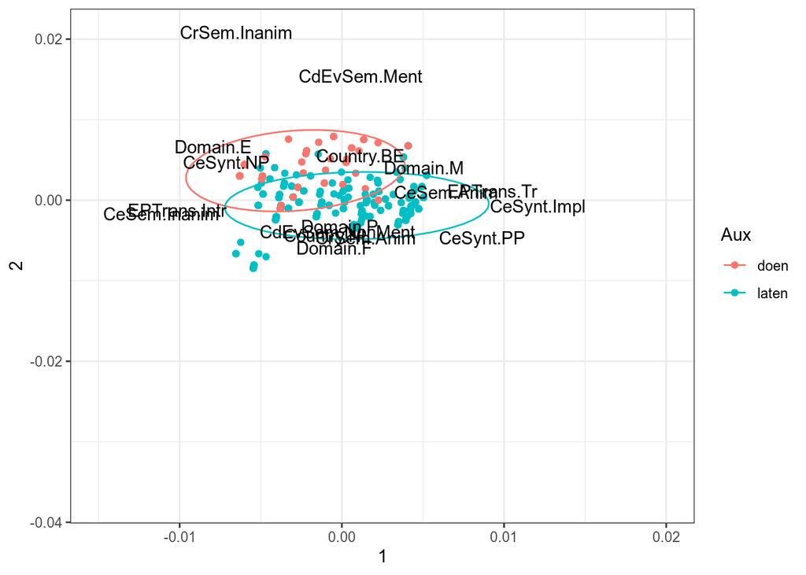

```r
variables$var_names <- rownames(MCA$cs)
dutch_caus %>%
  ggplot(aes(`1`, `2`))+
  geom_point(aes(color = Aux))+
  stat_ellipse(aes(color = Aux))+
  geom_text(data = variables, aes(`1`, `2`, label = var_names))+
  theme_bw()+
  scale_x_continuous(limits = c(-0.015, 0.02))
```

### 13. DCA

Комбинация CA и дискрименантного анализа называется Discriminant Correspondence Analysis.